# ナッジを活用した目のイラストによるゴミの分別促進に関する効果検証

2024-10-04

## 概要

本研究は、日本のリサイクル率の低さと、それに対するナッジ理論の有効性を検討。 特に「目のイラスト」や「社会規範」「簡素化メッセージ」といったナッジ手法がポスターを通じてごみ分別行動を促進するかを、**クラウドソーシングによるRCT（ランダム化比較試験）**で検証。

### ライブラリ読込

```r
#install.packages("pacman")
pacman::p_load(
  tidyverse,
  ggplotgui,#ggplot_shiny(exdataset)
  GGally,
  broom,
  kableExtra,
  ### table1を表にしてまとめやすく
  table1,
  sjPlot
)
```

### 元データ読み込み

```r
Data <- read_csv("../trash_data/AllData_trash.csv")
```

```
## ──────────────────────────────────────────────────────── Delimiter: "," chr
## (10): TimeStamp, SurvayType, ChooseHigh_Phrases1, ChooseHigh_Phrases2, C... dbl
## (6): ...1, PosterScore, ChooseHigh_Poster, ChooseLow_Poster, Awareness_...
```

### 不必要な３列は削除

```r
AllData <- Data %>%
  select(-ChooseHigh_Phrases1, -ChooseHigh_Phrases2, -ChooseHigh_Phrases3) %>%
  filter(SurvayType != "B1")

head(AllData)
```

```
## # A tibble: 6 × 13
##    ...1 TimeStamp      SurvayType PosterScore ChooseHigh_Poster ChooseLow_Poster
##   <dbl> <chr>          <chr>            <dbl>             <dbl>            <dbl>
## 1     1 8/21/2024 11:… A1                  30                 3                4
## 2     2 8/21/2024 11:… A1                  30                 3                1
## 3     3 8/21/2024 11:… A1                  40                 3                1
## 4     4 8/21/2024 11:… A1                  86                 1                2
## 5     5 8/21/2024 11:… A1                  22                 2                1
## 6     6 8/21/2024 11:… A1                   5                 1                3
## # ℹ 7 more variables: Age <chr>, Sex <chr>, ThrowOut <chr>,
## #   Awareness_Tra <dbl>, Awareness_Env <dbl>, Thoughts <chr>, Acton <chr>
```

# 研究1：目のイラストによる効果比較

# 1. データ前処理

### 分析に必要な4種類のSurvayTypeを抽出したdfを作成

```r
Eye_Illust_data <- AllData %>%
  # 目のイラストを比較するために必要なデータのみ抽出
  filter(SurvayType %in% c("C", "A1","A2","A4"))

Eye_Illust_data <- Eye_Illust_data %>%
  mutate(SurvayType = replace(SurvayType, SurvayType == "C", "イラストなし")) %>%
  mutate(SurvayType = replace(SurvayType, SurvayType == "A1", "複雑な目")) %>%
  mutate(SurvayType = replace(SurvayType, SurvayType == "A2", "女性の目")) %>%
  mutate(SurvayType = replace(SurvayType, SurvayType == "A4", "簡単な目"))


# C案（イラストがNo_image）がInterceptになるように調整
Eye_Illust_data$SurvayType <- factor(Eye_Illust_data$SurvayType, levels = c("イラストなし", "女性の目", "簡単な目", "複雑な目"))
```

## 記述統計量の作成（ポスター案と性別間比較）

```r
summary_by_survay <- Eye_Illust_data %>%
  #ポスター案ごとのグループ化
  group_by(SurvayType) %>%
  #ポスター案別のポスタースコア平均
  summarise(
    count = n(),
    Score_mean = round(mean(PosterScore), 2),
    Score_sd = round(sd(PosterScore), 2),
    Score_se = round(sd(PosterScore) / sqrt(n()), 2),
    Score_median = round(median(PosterScore), 2),
    Score_IQR = round(IQR(PosterScore), 2),
    Survay_Q1 = round(quantile(PosterScore, 0.25), 2),
    Survay_Q3 = round(quantile(PosterScore, 0.75), 2),
    Score_min = min(PosterScore),
    Score_max = max(PosterScore),
    male = sum(Sex == "male"),
    female = sum(Sex == "female"),
    other = sum(Sex == "other"))


#summary_by_survay
```

### 記述統計量 (wordに貼りやすくする)

```r
table1(~ factor(Sex) + PosterScore | SurvayType, data = Eye_Illust_data)
```

|  | イラストなし (N=100) | 女性の目 (N=104) | 簡単な目 (N=111) | 複雑な目 (N=99) | Overall (N=414) |
| --- | --- | --- | --- | --- | --- |
| factor(Sex) |  |  |  |  |  |
| female | 38 (38.0%) | 43 (41.3%) | 50 (45.0%) | 45 (45.5%) | 176 (42.5%) |
| male | 61 (61.0%) | 57 (54.8%) | 56 (50.5%) | 52 (52.5%) | 226 (54.6%) |
| other | 1 (1.0%) | 4 (3.8%) | 5 (4.5%) | 2 (2.0%) | 12 (2.9%) |
| PosterScore |  |  |  |  |  |
| Mean (SD) | 48.3 (31.5) | 45.7 (33.2) | 49.4 (31.3) | 37.9 (30.3) | 45.5 (31.8) |
| Median [Min, Max] | 50.0 [2.00, 100] | 50.0 [1.00, 100] | 55.0 [3.00, 100] | 33.0 [1.00, 100] | 50.0 [1.00, 100] |

### 記述統計量

```r
library(psych)
describeBy(Eye_Illust_data, group = Eye_Illust_data$SurvayType)
```

```
##
##  Descriptive statistics by group
## group: イラストなし
##                   vars   n   mean     sd median trimmed    mad min max range
## ...1                 1 100 686.50  29.01  686.5  686.50  37.06 637 736    99
## TimeStamp            2 100 174.89 101.70  168.5  172.88 123.06   2 372   370
## SurvayType           3 100   1.00   0.00    1.0    1.00   0.00   1   1     0
## PosterScore          4 100  48.25  31.45   50.0   47.81  37.06   2 100    98
## ChooseHigh_Poster    5 100   2.75   0.90    3.0    2.79   1.48   1   4     3
## ChooseLow_Poster     6 100   2.00   1.22    1.0    1.88   0.00   1   4     3
## Age                  7 100   4.61   1.18    5.0    4.60   1.48   2   8     6
## Sex                  8 100   1.63   0.51    2.0    1.65   0.00   1   3     2
## ThrowOut             9 100   2.62   0.79    3.0    2.77   0.00   1   3     2
## Awareness_Tra       10 100   3.62   0.79    4.0    3.60   1.48   2   5     3
## Awareness_Env       11 100   3.37   0.76    3.0    3.38   0.74   2   5     3
## Thoughts            12  34  71.06  30.16   76.0   72.68  25.95   7 116   109
## Acton               13  36  54.58  30.91   58.0   54.50  34.10   3 107   104
##                    skew kurtosis    se
## ...1               0.00    -1.24  2.90
## TimeStamp          0.15    -1.15 10.17
## SurvayType          NaN      NaN  0.00
## PosterScore       -0.07    -1.25  3.15
## ChooseHigh_Poster -0.15    -0.87  0.09
## ChooseLow_Poster   0.59    -1.37  0.12
## Age                0.16    -0.12  0.12
## Sex               -0.30    -1.37  0.05
## ThrowOut          -1.56     0.43  0.08
## Awareness_Tra      0.03    -0.54  0.08
## Awareness_Env      0.23    -0.29  0.08
## Thoughts          -0.47    -0.66  5.17
## Acton             -0.05    -1.18  5.15
## ------------------------------------------------------------
## group: 女性の目
##                   vars   n   mean     sd median trimmed    mad min max range
## ...1                 1 104 151.50  30.17  151.5  151.50  38.55 100 203   103
## TimeStamp            2 104 189.26 111.26  198.5  189.82 139.36   1 369   368
## SurvayType           3 104   2.00   0.00    2.0    2.00   0.00   2   2     0
## PosterScore          4 104  45.74  33.21   50.0   44.76  44.48   1 100    99
## ChooseHigh_Poster    5 104   2.70   0.87    3.0    2.71   1.48   1   4     3
## ChooseLow_Poster     6 104   1.95   1.29    1.0    1.82   0.00   1   4     3
```

[output cut: 66 more lines]

```
## Acton               13 20  56.60  31.20   62.5   57.50  40.03   1 104   103
##                    skew kurtosis    se
## ...1               0.00    -1.24  2.89
## TimeStamp          0.01    -1.36 11.63
## SurvayType          NaN      NaN  0.00
## PosterScore        0.46    -1.02  3.04
## ChooseHigh_Poster -0.23    -0.67  0.09
## ChooseLow_Poster   0.47    -1.49  0.13
## Age               -0.16    -0.33  0.12
## Sex                0.13    -1.20  0.05
## ThrowOut          -1.86     1.52  0.07
## Awareness_Tra     -0.58     0.40  0.09
## Awareness_Env     -0.40     0.13  0.10
## Thoughts          -0.23    -1.19  6.16
## Acton             -0.20    -1.37  6.98
```

# 2. 可視化

### ヒストグラム(全データ)

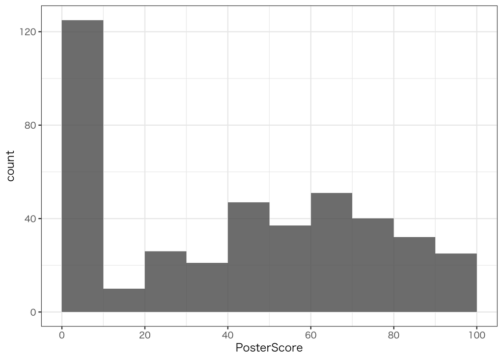

```r
graph <- ggplot(Eye_Illust_data, aes(x = PosterScore)) +

  geom_histogram(position = 'identity',alpha = 0.8,binwidth = 10,boundary = 0) +　#boundary = 0で0が帯の左に
  scale_x_continuous(breaks = seq(0, max(Eye_Illust_data$PosterScore, na.rm = TRUE),by = 20), limits = c(0, NA)) +
  # 横軸の最小値を0に設定
  theme_bw(base_family = "HiraKakuPro-W3")


graph
```

### ヒストグラム(4群比較)

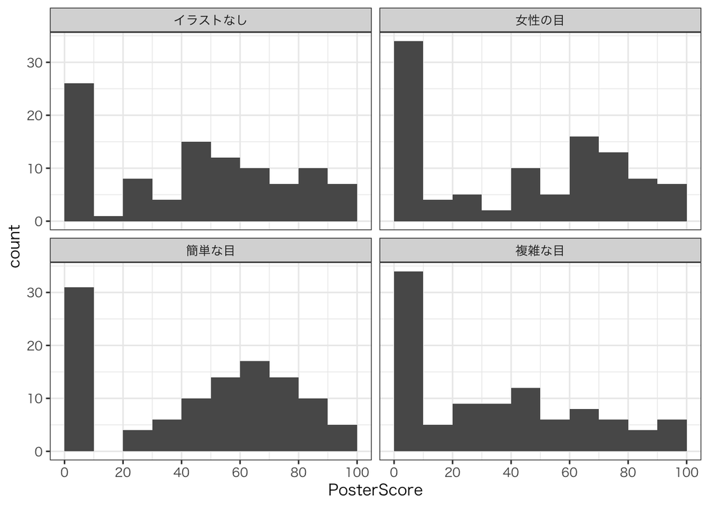

```r
graph <- ggplot(Eye_Illust_data, aes(x = PosterScore)) +
  geom_histogram(position = 'identity', alpha = 1, binwidth = 10, boundary = 0) +
  facet_wrap( . ~ SurvayType, ncol = 2, nrow = 2 ) +　#表示を２行２列に、ポスター案ごとの分類
  scale_x_continuous(breaks = seq(0, max(Eye_Illust_data$PosterScore, na.rm = TRUE),by = 20), limits = c(0, NA)) +
  theme_bw(base_family = "HiraKakuPro-W3")

graph
```

### プロットグラフ(4群比較)

```
## No summary function supplied, defaulting to `mean_se()`
```

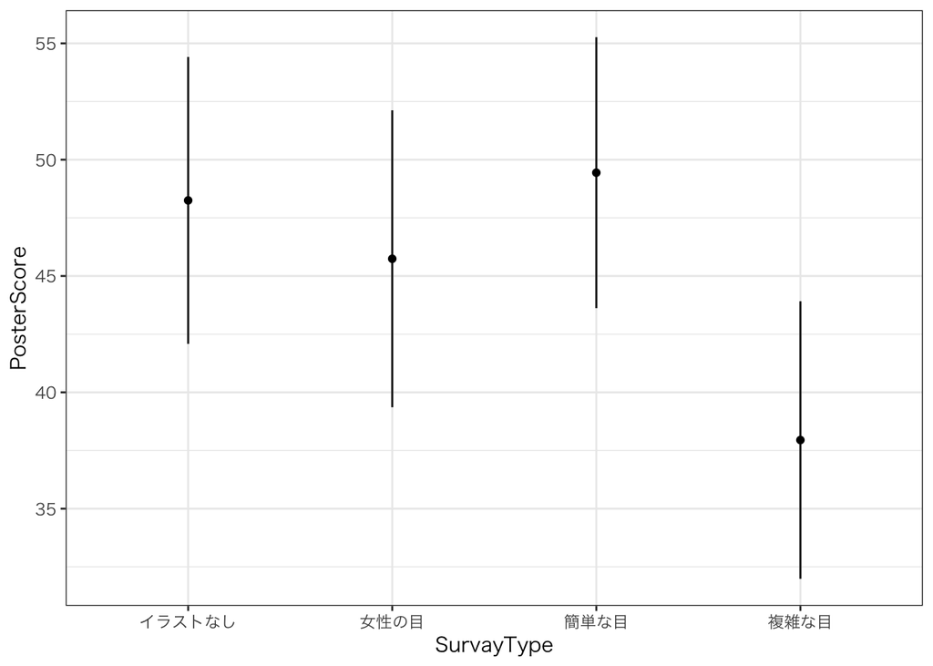

```r
graph <- ggplot(Eye_Illust_data, aes(x = SurvayType, y = PosterScore)) +
  geom_point(stat = 'summary', fun.y = 'mean') +
  geom_errorbar(stat = 'summary', fun.data = 'mean_se',
                width=0, fun.args = list(mult = 1.96)) +
  theme_bw(base_family = "HiraKakuPro-W3") # base_family = "HiraKakuPro-W3"
graph
```

# 3. 統計解析

## 分散分析

- H1)目のイラスト`SurvayType`によってポスターの評価`PosterScore`は異なる。
- H0)目のイラスト`SurvayType`によってポスターの評価`PosterScore`は異なるというわけではない。
- 目のイラストが無いポスター案Cを対照群とし、その３種の目のイラストがあるポスター案をそれぞれ比較郡として、**目のイラストによる介入がポスターの評価スコアに影響を与えるのか調査しました。**
- `Sex`と`Age`のother回答も含めた分析。
- [共変量あり]と[共変量なし]の両方のモデルを実行して比較します。

### モデル作成（共変量なし）

```r
Eye_Illust_model <- lm(PosterScore ~ SurvayType, Eye_Illust_data)
```

### モデル（共変量あり）

- Age, Sex, Awareness_Tra, Awareness_Envを共変量として重回帰分析をする
- 興味としてはSurvayTypeのみ

```r
Eye_Illust_model2 <- lm(PosterScore ~ SurvayType + Age + Sex + Awareness_Tra + Awareness_Env, Eye_Illust_data)
```

### 分散分析結果

```r
#共変量なし
summary(Eye_Illust_model)
```

```
##
## Call:
## lm(formula = PosterScore ~ SurvayType, data = Eye_Illust_data)
##
## Residuals:
##     Min      1Q  Median      3Q     Max
## -46.441 -32.949   2.051  26.452  62.051
##
## Coefficients:
##                    Estimate Std. Error t value Pr(>|t|)
## (Intercept)          48.250      3.159  15.275   <2e-16 ***
## SurvayType女性の目   -2.510      4.424  -0.567    0.571
## SurvayType簡単な目    1.191      4.355   0.274    0.785
## SurvayType複雑な目  -10.301      4.479  -2.300    0.022 *
## ---
## Signif. codes:  0 '***' 0.001 '**' 0.01 '*' 0.05 '.' 0.1 ' ' 1
##
## Residual standard error: 31.59 on 410 degrees of freedom
## Multiple R-squared:  0.01949,    Adjusted R-squared:  0.01231
## F-statistic: 2.716 on 3 and 410 DF,  p-value: 0.04443
```

```r
#共変量あり
summary(Eye_Illust_model2)
```

```
##
## Call:
## lm(formula = PosterScore ~ SurvayType + Age + Sex + Awareness_Tra +
##     Awareness_Env, data = Eye_Illust_data)
##
## Residuals:
##     Min      1Q  Median      3Q     Max
## -53.873 -29.935   2.571  26.130  66.098
##
## Coefficients:
##                    Estimate Std. Error t value Pr(>|t|)
## (Intercept)          27.062     17.581   1.539  0.12453
## SurvayType女性の目   -2.229      4.443  -0.502  0.61618
## SurvayType簡単な目    0.665      4.394   0.151  0.87978
## SurvayType複雑な目  -11.569      4.487  -2.578  0.01029 *
## Age20dai            -10.345     17.850  -0.580  0.56255
## Age30dai             -3.602     16.531  -0.218  0.82763
## Age40dai             -5.868     16.196  -0.362  0.71732
## Age50dai             -7.087     16.241  -0.436  0.66280
## Age60dai            -10.738     16.536  -0.649  0.51646
## Age70dai            -11.308     17.260  -0.655  0.51276
## Ageother            -25.020     23.270  -1.075  0.28294
## Sexmale               3.693      3.209   1.151  0.25042
## Sexother             20.088     14.557   1.380  0.16838
## Awareness_Tra         5.953      2.210   2.694  0.00736 **
## Awareness_Env         1.334      2.291   0.582  0.56079
## ---
## Signif. codes:  0 '***' 0.001 '**' 0.01 '*' 0.05 '.' 0.1 ' ' 1
##
## Residual standard error: 31.36 on 399 degrees of freedom
## Multiple R-squared:  0.05976,    Adjusted R-squared:  0.02677
## F-statistic: 1.811 on 14 and 399 DF,  p-value: 0.03504
```

### 推定表

```r
tab_model(Eye_Illust_model, Eye_Illust_model2,
          show.aic = T)
```

|  | PosterScore |  |  | PosterScore |  |  |
| --- | --- | --- | --- | --- | --- | --- |
| Predictors | Estimates | CI | p | Estimates | CI | p |
| (Intercept) | 48.25 | 42.04 – 54.46 | **<0.001** | 27.06 | -7.50 – 61.63 | 0.125 |
| SurvayType [女性の目] | -2.51 | -11.21 – 6.19 | 0.571 | -2.23 | -10.96 – 6.51 | 0.616 |
| SurvayType [簡単な目] | 1.19 | -7.37 – 9.75 | 0.785 | 0.67 | -7.97 – 9.30 | 0.880 |
| SurvayType [複雑な目] | -10.30 | -19.10 – -1.50 | **0.022** | -11.57 | -20.39 – -2.75 | **0.010** |
| Age [20dai] |  |  |  | -10.35 | -45.44 – 24.75 | 0.563 |
| Age [30dai] |  |  |  | -3.60 | -36.10 – 28.90 | 0.828 |
| Age [40dai] |  |  |  | -5.87 | -37.71 – 25.97 | 0.717 |
| Age [50dai] |  |  |  | -7.09 | -39.02 – 24.84 | 0.663 |
| Age [60dai] |  |  |  | -10.74 | -43.25 – 21.77 | 0.516 |
| Age [70dai] |  |  |  | -11.31 | -45.24 – 22.62 | 0.513 |
| Age [other] |  |  |  | -25.02 | -70.77 – 20.73 | 0.283 |
| Sex [male] |  |  |  | 3.69 | -2.62 – 10.00 | 0.250 |
| Sex [other] |  |  |  | 20.09 | -8.53 – 48.71 | 0.168 |
| Awareness Tra |  |  |  | 5.95 | 1.61 – 10.30 | **0.007** |
| Awareness Env |  |  |  | 1.33 | -3.17 – 5.84 | 0.561 |
| Observations | 414 |  |  | 414 |  |  |
| R<sup>2</sup> / R<sup>2</sup> adjusted | 0.019 / 0.012 |  |  | 0.060 / 0.027 |  |  |
| AIC | 4039.767 |  |  | 4044.405 |  |  |

### model1の分散分析表の出力（共変量無）

```r
anova_result1 <- anova(Eye_Illust_model) %>%
  tidy() %>%
  mutate(across(where(is.numeric), ~ round(., 3))) # 小数点第3位で四捨五入

#分散分析表の出力
anova_result1
```

```
## # A tibble: 2 × 6
##   term          df   sumsq meansq statistic p.value
##   <chr>      <dbl>   <dbl>  <dbl>     <dbl>   <dbl>
## 1 SurvayType     3   8130.  2710.      2.72   0.044
## 2 Residuals    410 409105.   998.     NA     NA
```

```r
# ANOVA結果をHTMLテーブルで出力
anova_result1 %>%
  kable(format = "html", caption = "ANOVA Results") %>%
  kable_styling(bootstrap_options = c("striped", "hover", "condensed", "responsive"))
```

ANOVA Results

| term | df | sumsq | meansq | statistic | p.value |
| --- | --- | --- | --- | --- | --- |
| SurvayType | 3 | 8130.401 | 2710.134 | 2.716 | 0.044 |
| Residuals | 410 | 409104.857 | 997.817 | NA | NA |

### model2の分散分析表の出力（共変量アリ）

```r
anova_result2 <- anova(Eye_Illust_model2) %>%
  tidy() %>%
  mutate(across(where(is.numeric), ~ round(., 3))) # 小数点第3位で四捨五入

anova_result2
```

```
## # A tibble: 6 × 6
##   term             df   sumsq meansq statistic p.value
##   <chr>         <dbl>   <dbl>  <dbl>     <dbl>   <dbl>
## 1 SurvayType        3   8130.  2710.     2.76    0.042
## 2 Age               7   1764.   252.     0.256   0.97
## 3 Sex               2   1544.   772.     0.785   0.457
## 4 Awareness_Tra     1  13162. 13162.    13.4     0
## 5 Awareness_Env     1    333.   333.     0.339   0.561
## 6 Residuals       399 392302.   983.    NA      NA
```

```r
# ANOVA結果をHTMLテーブルで出力
anova_result2 %>%
  kable(format = "html", caption = "ANOVA Results") %>%
  kable_styling(bootstrap_options = c("striped", "hover", "condensed", "responsive"))
```

ANOVA Results

| term | df | sumsq | meansq | statistic | p.value |
| --- | --- | --- | --- | --- | --- |
| SurvayType | 3 | 8130.401 | 2710.134 | 2.756 | 0.042 |
| Age | 7 | 1763.740 | 251.963 | 0.256 | 0.970 |
| Sex | 2 | 1544.212 | 772.106 | 0.785 | 0.457 |
| Awareness_Tra | 1 | 13161.665 | 13161.665 | 13.386 | 0.000 |
| Awareness_Env | 1 | 333.225 | 333.225 | 0.339 | 0.561 |
| Residuals | 399 | 392302.016 | 983.213 | NA | NA |

## ノンパラメトリック検定

ヒストグラムより、PosterScoreの分布は正規分布に従わないことが示唆されるため、ノンパラメトリック検定を実施する。

### 正規性の検定(Shapiro-Wilk test)

H0)それぞれの`SurvayType`における`PosterScore`の分布は正規分布に従う。

H1)それぞれの`SurvayType`における`PosterScore`の分布は正規分布に従うというわけではない。

```r
#SurvayTypeごとの正規性検定
tapply(Eye_Illust_data$PosterScore, Eye_Illust_data$SurvayType,
       shapiro.test)
```

```
## $イラストなし
##
##  Shapiro-Wilk normality test
##
## data:  X[[i]]
## W = 0.91989, p-value = 1.388e-05
##
##
## $女性の目
##
##  Shapiro-Wilk normality test
##
## data:  X[[i]]
## W = 0.88299, p-value = 1.568e-07
##
##
## $簡単な目
##
##  Shapiro-Wilk normality test
##
## data:  X[[i]]
## W = 0.89234, p-value = 1.995e-07
##
##
## $複雑な目
##
##  Shapiro-Wilk normality test
##
## data:  X[[i]]
## W = 0.9048, p-value = 2.646e-06
```

データの正規性と等分散性を検討するため、シャピロ・ウィルク検定を実施した。シャピロ・ウィルク検定の結果、全てのグループで正規性が否定された（p < 0.05）。

### 等分散性の検定(Levene’s test)

H0)それぞれの`SurvayType`における`PosterScore`の分布は等分散である。

H1)それぞれの`SurvayType`における`PosterScore`の分布は等分散ではない。

```r
#install.packages("car")  # 初回のみ
library(car) #等分散性の検定(Levene's test)
# ルビーンの検定の実施
levene_result <- leveneTest(Eye_Illust_data$PosterScore ~ Eye_Illust_data$SurvayType,
                            Eye_Illust_data)
levene_result
```

```
## Levene's Test for Homogeneity of Variance (center = median)
##        Df F value Pr(>F)
## group   3  1.2164 0.3033
##       410
```

### ４つのグループにおける差の検定(Kruskal-Wallis test)

```r
# クラスカル・ウォリス検定の実施
kruskal_result <- kruskal.test(Eye_Illust_data$PosterScore ~ Eye_Illust_data$SurvayType)

kruskal_result
```

```
##
##  Kruskal-Wallis rank sum test
##
## data:  Eye_Illust_data$PosterScore by Eye_Illust_data$SurvayType
## Kruskal-Wallis chi-squared = 7.5909, df = 3, p-value = 0.05527
```

### グループ間における事後検定(Dunn の多重比較検定でHolm 補正)

```r
#install.packages("FSA")
library(FSA)
dunnTest(
  PosterScore ~ SurvayType,
  data   = Eye_Illust_data,
  method = "holm"   # Holm 補正
)
```

```
## Dunn (1964) Kruskal-Wallis multiple comparison
```

```
##   p-values adjusted with the Holm method.
```

```
##                Comparison          Z    P.unadj      P.adj
## 1 イラストなし - 女性の目  0.3753545 0.70739686 1.00000000
## 2 イラストなし - 簡単な目 -0.3448210 0.73022891 0.73022891
## 3     女性の目 - 簡単な目 -0.7335746 0.46320807 1.00000000
## 4 イラストなし - 複雑な目  2.1624844 0.03058086 0.15290429
## 5     女性の目 - 複雑な目  1.8090830 0.07043811 0.28175244
## 6     簡単な目 - 複雑な目  2.5617544 0.01041449 0.06248696
```

# 研究2：イラスト３×フレーズ３の比較分析

#### 分析に必要な９種類のSurvayTypeを抽出したdfを作成

```r
cross_data <- AllData %>%
  # イラストとフレーズを3*3で比較するために必要なデータのみ抽出
  filter(SurvayType %in% c("F","G","C","H","I","A4","J","K","A3"))
```

### リネームと変数の分割、並び替え

- 変数`PhraseType`を作成し、対応するポスター案に適した名前に変更
  - ポスター案F, H, J の`PhraseType`は「**簡素化メッセージ**」に変更
- 変数`Illustration`を作成し、対応するポスター案に適した名前に変更
  - ポスター案F, G, C の`Illustration`は「**イラストなし**」に変更
- 変数`SurvayType`もアルファベットだとわかりにくいため、各条件に合わせた名前に変更
  - ポスター案Fの`SurvayType`は「**イラストなし & 簡素化メッセージ**」に変更
- 変数`PhraseType`と`Illustration`がdfの先頭列に来るように移動
- 分析時に比較群が左上に、以後の介入群が蛇行列になるよう並び替え

```r
cross_data2 <- cross_data %>%
  mutate(
    PhraseType = SurvayType,
    Illustration = SurvayType) %>%

  #フレーズタイプの分類
  mutate(
    PhraseType = case_when(
      SurvayType %in% c("F", "H", "J") ~ "簡素化メッセージ",
      SurvayType %in% c("G", "I", "K") ~ "社会規範メッセージ",
      SurvayType %in% c("C", "A4", "A3") ~ "基準メッセージ",
      TRUE ~ NA_character_  # 該当なしの場合
    ),

    #イラストタイプの分類
    Illustration = case_when(
      SurvayType %in% c("F", "G", "C") ~ "イラストなし",
      SurvayType %in% c("H", "I", "A4") ~ "目のイラスト",
      SurvayType %in% c("J", "K", "A3") ~ "社会規範イラスト",
      TRUE ~ NA_character_)
  ) %>%

    mutate(SurvayType = case_when(
      SurvayType == "F" ~ "イラストなし & 簡素化メッセージ",
      SurvayType == "G" ~ "イラストなし & 社会規範メッセージ",
      SurvayType == "C" ~ "イラストなし & 基準メッセージ",
      SurvayType == "H" ~ "目のイラスト & 簡素化メッセージ",
      SurvayType == "I" ~ "目のイラスト & 社会規範メッセージ",
      SurvayType == "A4" ~ "目のイラスト & 基準メッセージ",
      SurvayType == "J" ~ "社会規範イラスト & 簡素化メッセージ",
      SurvayType == "K" ~ "社会規範イラスト & 社会規範メッセージ",
      SurvayType == "A3" ~ "社会規範イラスト & 基準メッセージ",
      TRUE ~ SurvayType  # 他の値はそのまま
  )) %>%




  #フレーズとイラストのタイプ分類が先頭列に来るよう整備
  relocate(PhraseType, .after = SurvayType) %>%
  relocate(Illustration, .after = PhraseType)

# F案（フレーズがnormal, イラストがNo_image）がInterceptになるように調整
cross_data2$PhraseType <- factor(cross_data2$PhraseType, levels = c("基準メッセージ", "社会規範メッセージ", "簡素化メッセージ"))
cross_data2$Illustration <- factor(cross_data2$Illustration, levels = c("イラストなし", "目のイラスト", "社会規範イラスト"))

cross_data2
```

```
## # A tibble: 868 × 15
##     ...1 TimeStamp          SurvayType       PhraseType Illustration PosterScore
##    <dbl> <chr>              <chr>            <fct>      <fct>              <dbl>
##  1   204 8/21/2024 11:05:01 社会規範イラスト & 基準メッ… 基準メッセージ…… 社会規範イラスト……           4
##  2   205 8/21/2024 11:05:23 社会規範イラスト & 基準メッ… 基準メッセージ…… 社会規範イラスト……          57
##  3   206 8/21/2024 11:05:29 社会規範イラスト & 基準メッ… 基準メッセージ…… 社会規範イラスト……          72
##  4   207 8/21/2024 11:06:00 社会規範イラスト & 基準メッ… 基準メッセージ…… 社会規範イラスト……          80
##  5   208 8/21/2024 11:06:15 社会規範イラスト & 基準メッ… 基準メッセージ…… 社会規範イラスト……           6
##  6   209 8/21/2024 11:06:54 社会規範イラスト & 基準メッ… 基準メッセージ…… 社会規範イラスト……          10
##  7   210 8/21/2024 11:06:57 社会規範イラスト & 基準メッ… 基準メッセージ…… 社会規範イラスト……          50
##  8   211 8/21/2024 11:07:00 社会規範イラスト & 基準メッ… 基準メッセージ…… 社会規範イラスト……          30
##  9   212 8/21/2024 11:07:09 社会規範イラスト & 基準メッ… 基準メッセージ…… 社会規範イラスト……          82
## 10   213 8/21/2024 11:07:30 社会規範イラスト & 基準メッ… 基準メッセージ…… 社会規範イラスト……          70
## # ℹ 858 more rows
## # ℹ 9 more variables: ChooseHigh_Poster <dbl>, ChooseLow_Poster <dbl>,
## #   Age <chr>, Sex <chr>, ThrowOut <chr>, Awareness_Tra <dbl>,
## #   Awareness_Env <dbl>, Thoughts <chr>, Acton <chr>
```

### 記述統計量の確認

```r
### table1を表にしてまとめやすく
library(table1)
table1(~ factor(Sex) + PosterScore | SurvayType, data = cross_data2)
```

|  | イラストなし & 基準メッセージ (N=100) | イラストなし & 社会規範メッセージ (N=86) | イラストなし & 簡素化メッセージ (N=94) | 目のイラスト & 基準メッセージ (N=111) | 目のイラスト & 社会規範メッセージ (N=99) | 目のイラスト & 簡素化メッセージ (N=96) | 社会規範イラスト & 基準メッセージ (N=103) | 社会規範イラスト & 社会規範メッセージ (N=90) | 社会規範イラスト & 簡素化メッセージ (N=89) | Overall (N=868) |
| --- | --- | --- | --- | --- | --- | --- | --- | --- | --- | --- |
| factor(Sex) |  |  |  |  |  |  |  |  |  |  |
| female | 38 (38.0%) | 28 (32.6%) | 35 (37.2%) | 50 (45.0%) | 33 (33.3%) | 32 (33.3%) | 37 (35.9%) | 31 (34.4%) | 26 (29.2%) | 310 (35.7%) |
| male | 61 (61.0%) | 57 (66.3%) | 51 (54.3%) | 56 (50.5%) | 64 (64.6%) | 64 (66.7%) | 63 (61.2%) | 58 (64.4%) | 63 (70.8%) | 537 (61.9%) |
| other | 1 (1.0%) | 1 (1.2%) | 8 (8.5%) | 5 (4.5%) | 2 (2.0%) | 0 (0%) | 3 (2.9%) | 1 (1.1%) | 0 (0%) | 21 (2.4%) |
| PosterScore |  |  |  |  |  |  |  |  |  |  |
| Mean (SD) | 48.3 (31.5) | 47.7 (31.0) | 49.2 (30.7) | 49.4 (31.3) | 48.2 (30.1) | 46.4 (31.1) | 50.0 (32.7) | 51.2 (32.7) | 56.6 (30.4) | 49.6 (31.3) |
| Median [Min, Max] | 50.0 [2.00, 100] | 59.0 [3.00, 100] | 55.0 [1.00, 100] | 55.0 [3.00, 100] | 50.0 [2.00, 100] | 51.5 [4.00, 100] | 55.0 [2.00, 100] | 60.0 [3.00, 100] | 65.0 [1.00, 100] | 55.0 [1.00, 100] |

## グラフ

### データの分布（全データ）

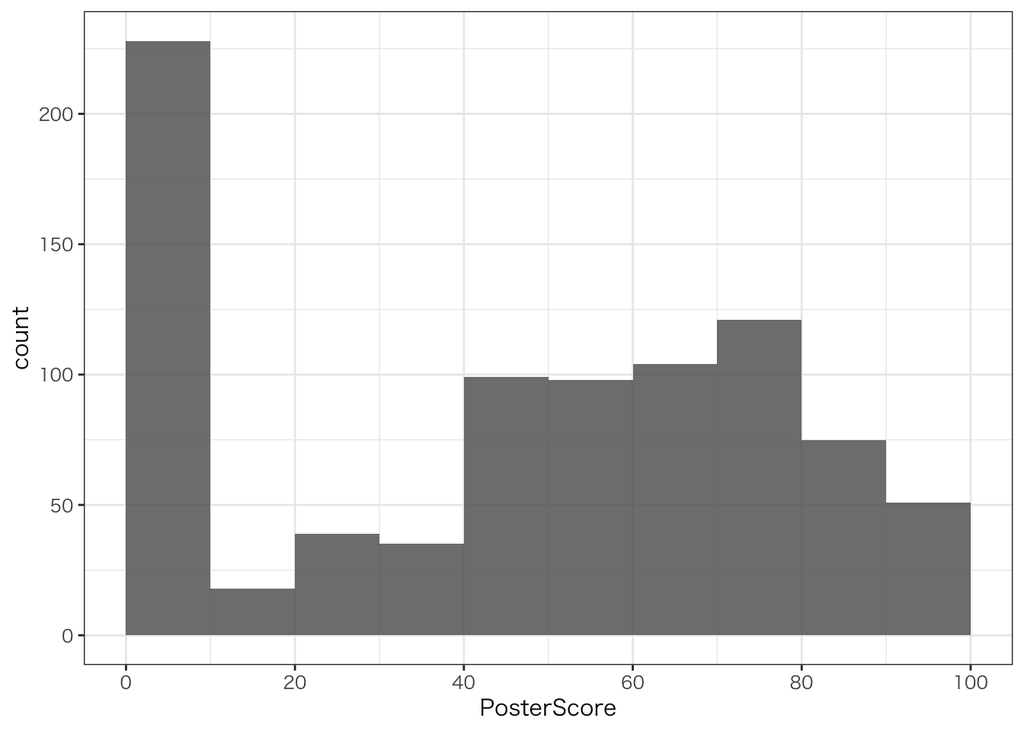

```r
# The code below will generate the graph:
graph <- ggplot(cross_data2, aes(x = PosterScore)) +


  geom_histogram(
    position = 'identity',
    alpha = 0.8,
    binwidth = 10,
    boundary = 0                                      #boundary = 0で0が帯の左に
  ) +


  scale_x_continuous(
    breaks = seq(0,
                 max(cross_data2$PosterScore,
                 na.rm = TRUE),by = 20),

    limits = c(0, NA)                                 # 横軸の最小値を0に設定
  ) +


  theme_bw(base_family = "HiraKakuPro-W3")


graph
```

### データの分布(各群)

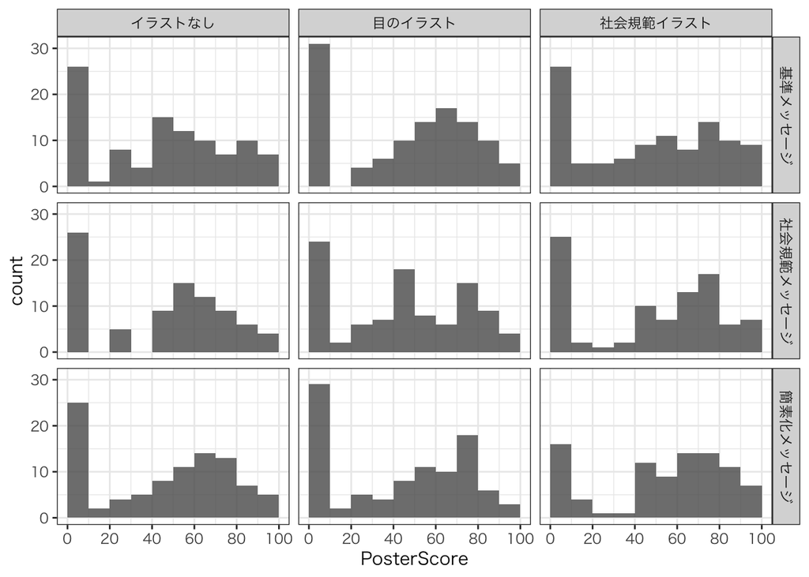

```r
# The code below will generate the graph:
graph <- ggplot(cross_data2, aes(x = PosterScore)) +
  geom_histogram(position = 'identity', alpha = 0.8, binwidth = 10, boundary = 0) +
  facet_grid( PhraseType ~ Illustration ) +
  scale_x_continuous(breaks = seq(0, max(cross_data2$PosterScore, na.rm = TRUE),by = 20), limits = c(0, NA)) +
  theme_bw(base_family = "HiraKakuPro-W3")

graph
```

### フレーズとイラストでグリッドしたグラフ

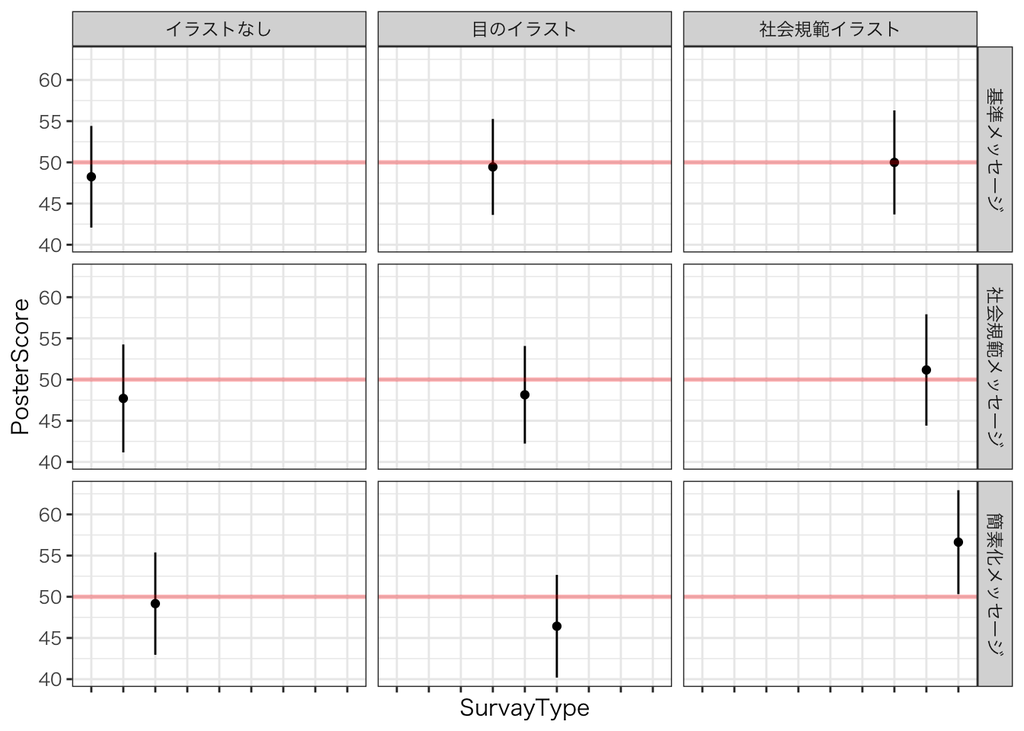

```r
graph <- ggplot(cross_data2, aes(x = SurvayType, y = PosterScore)) +
  # 平均を表示
  geom_point(stat = 'summary', fun = mean) +
  # 95%信頼区間のエラーバーを表示
  geom_errorbar(stat = 'summary', fun.data = mean_se,
                width = 0, fun.args = list(mult = 1.96)) +
  # x=50の位置に赤くて太い線を追加
  geom_hline(yintercept = 50, color = "red", size = 1, alpha = 0.3) +

  # 9つのグラフを分けて表示
  facet_grid(PhraseType ~ Illustration) +

  # グラフのテーマ設定
  theme_bw(base_family = "HiraKakuPro-W3") +

  #x軸の値を記載しない
  theme(axis.text.x = element_blank())
graph
```

## 分析方法

#### 各要因が３水準の二要因分散分析(Two-way ANOVA)

- H1)イラスト`PhraseType`とフレーズ`Illustration`によってポスターの評価`PosterScore`は異なる。
- H0)イラスト`PhraseType`とフレーズ`Illustration`によってポスターの評価`PosterScore`は異なるというわけではない。

## 分析

#### モデル作 - **交互作用なし**

```r
Score_model_noint1 <- lm(PosterScore ~ PhraseType + Illustration, cross_data2)#共変量なし
Score_model_noint2 <- lm(PosterScore ~ PhraseType + Illustration + Age + Sex + Awareness_Tra + Awareness_Env, cross_data2)#共変量あり
```

#### モデル構築 - **交互作用あり**

```r
Score_model_int1 <- lm(PosterScore ~ PhraseType * Illustration, cross_data2) #モデル（共変量なし)
Score_model_int2 <- lm(PosterScore ~ PhraseType * Illustration + Age + Sex + Awareness_Tra + Awareness_Env, cross_data2)#モデル（共変量あり)
```

#### anovaのHTML出力

- Model1（交互作用なし、共変量なし）

```r
# ANOVAの実行例
anova_result_model1 <- anova(Score_model_noint1) %>%
  tidy()

#出力結果
anova_result_model1
```

```
## # A tibble: 3 × 6
##   term            df   sumsq meansq statistic p.value
##   <chr>        <int>   <dbl>  <dbl>     <dbl>   <dbl>
## 1 PhraseType       2    421.   211.     0.216   0.806
## 2 Illustration     2   3442.  1721.     1.76    0.173
## 3 Residuals      863 843526.   977.    NA      NA
```

```r
# ANOVA結果をHTMLテーブルで出力
anova_result_model1 %>%
  kable(format = "html", caption = "ANOVA Results") %>%
  kable_styling(bootstrap_options = c("striped", "hover", "condensed", "responsive"))
```

ANOVA Results

| term | df | sumsq | meansq | statistic | p.value |
| --- | --- | --- | --- | --- | --- |
| PhraseType | 2 | 421.4323 | 210.7161 | 0.2155808 | 0.8061165 |
| Illustration | 2 | 3442.2785 | 1721.1393 | 1.7608743 | 0.1725115 |
| Residuals | 863 | 843525.9574 | 977.4345 | NA | NA |

- Model2（交互作用あり、共変量なし）

```r
# ANOVAの実行例
anova_result_model3 <- anova(Score_model_int1) %>%
  tidy()

#出力結果
anova_result_model3
```

```
## # A tibble: 4 × 6
##   term                       df   sumsq meansq statistic p.value
##   <chr>                   <int>   <dbl>  <dbl>     <dbl>   <dbl>
## 1 PhraseType                  2    421.   211.     0.215   0.806
## 2 Illustration                2   3442.  1721.     1.76    0.173
## 3 PhraseType:Illustration     4   2454.   614.     0.627   0.644
## 4 Residuals                 859 841072.   979.    NA      NA
```

```r
# ANOVA結果をHTMLテーブルで出力
anova_result_model3 %>%
  kable(format = "html", caption = "ANOVA Results") %>%
  kable_styling(bootstrap_options = c("striped", "hover", "condensed", "responsive"))
```

ANOVA Results

| term | df | sumsq | meansq | statistic | p.value |
| --- | --- | --- | --- | --- | --- |
| PhraseType | 2 | 421.4323 | 210.7161 | 0.2152078 | 0.8064173 |
| Illustration | 2 | 3442.2785 | 1721.1393 | 1.7578273 | 0.1730387 |
| PhraseType:Illustration | 4 | 2454.3577 | 613.5894 | 0.6266688 | 0.6435731 |
| Residuals | 859 | 841071.5997 | 979.1288 | NA | NA |

- Model3（交互作用なし、共変量あり）

```r
# ANOVAの実行例
anova_result_model2 <- anova(Score_model_noint2) %>%
  tidy()

#出力結果
anova_result_model1
```

[output not shown]

```r
# ANOVA結果をHTMLテーブルで出力
anova_result_model2 %>%
  kable(format = "html", caption = "ANOVA Results") %>%
  kable_styling(bootstrap_options = c("striped", "hover", "condensed", "responsive"))
```

ANOVA Results

| term | df | sumsq | meansq | statistic | p.value |
| --- | --- | --- | --- | --- | --- |
| PhraseType | 2 | 421.4323 | 210.7161 | 0.2151100 | 0.8064965 |
| Illustration | 2 | 3442.2785 | 1721.1393 | 1.7570284 | 0.1731815 |
| Age | 7 | 1740.2355 | 248.6051 | 0.2537890 | 0.9710139 |
| Sex | 2 | 803.8788 | 401.9394 | 0.4103206 | 0.6635685 |
| Awareness_Tra | 1 | 5033.7987 | 5033.7987 | 5.1387631 | 0.0236472 |
| Awareness_Env | 1 | 1351.0107 | 1351.0107 | 1.3791819 | 0.2405687 |
| Residuals | 852 | 834597.0338 | 979.5740 | NA | NA |

- Model4（交互作用あり、共変量あり）

```r
# ANOVAの実行例
anova_result_model4 <- anova(Score_model_int2) %>%
  tidy()

#出力結果
anova_result_model4
```

```
## # A tibble: 8 × 6
##   term                       df   sumsq meansq statistic p.value
##   <chr>                   <int>   <dbl>  <dbl>     <dbl>   <dbl>
## 1 PhraseType                  2    421.   211.     0.215  0.807
## 2 Illustration                2   3442.  1721.     1.75   0.174
## 3 Age                         7   1740.   249.     0.253  0.971
## 4 Sex                         2    804.   402.     0.410  0.664
## 5 Awareness_Tra               1   5034.  5034.     5.13   0.0238
## 6 Awareness_Env               1   1351.  1351.     1.38   0.241
## 7 PhraseType:Illustration     4   2255.   564.     0.574  0.681
## 8 Residuals                 848 832342.   982.    NA     NA
```

```r
# ANOVA結果をHTMLテーブルで出力
anova_result_model4 %>%
  kable(format = "html", caption = "ANOVA Results") %>%
  kable_styling(bootstrap_options = c("striped", "hover", "condensed", "responsive"))
```

ANOVA Results

| term | df | sumsq | meansq | statistic | p.value |
| --- | --- | --- | --- | --- | --- |
| PhraseType | 2 | 421.4323 | 210.7161 | 0.2146800 | 0.8068434 |
| Illustration | 2 | 3442.2785 | 1721.1393 | 1.7535164 | 0.1737913 |
| Age | 7 | 1740.2355 | 248.6051 | 0.2532817 | 0.9711770 |
| Sex | 2 | 803.8788 | 401.9394 | 0.4095005 | 0.6641131 |
| Awareness_Tra | 1 | 5033.7987 | 5033.7987 | 5.1284916 | 0.0237879 |
| Awareness_Env | 1 | 1351.0107 | 1351.0107 | 1.3764251 | 0.2410405 |
| PhraseType:Illustration | 4 | 2254.5785 | 563.6446 | 0.5742476 | 0.6813904 |
| Residuals | 848 | 832342.4553 | 981.5359 | NA | NA |

### 推定表

```r
tab_model(Score_model_noint1, Score_model_int1, Score_model_noint2, Score_model_int2,
          show.aic = T)
```

|  | PosterScore |  |  | PosterScore |  |  | PosterScore |  |  | PosterScore |  |  |
| --- | --- | --- | --- | --- | --- | --- | --- | --- | --- | --- | --- | --- |
| Predictors | Estimates | CI | p | Estimates | CI | p | Estimates | CI | p | Estimates | CI | p |
| (Intercept) | 48.00 | 43.39 – 52.60 | **<0.001** | 48.25 | 42.11 – 54.39 | **<0.001** | 40.64 | 11.56 – 69.72 | **0.006** | 40.11 | 10.57 – 69.66 | **0.008** |
| PhraseType [社会規範メッセージ] | -0.24 | -5.31 – 4.83 | 0.927 | -0.54 | -9.57 – 8.49 | 0.906 | -0.46 | -5.57 – 4.66 | 0.861 | -1.03 | -10.11 – 8.04 | 0.823 |
| PhraseType [簡素化メッセージ] | 1.40 | -3.65 – 6.45 | 0.587 | 0.92 | -7.90 – 9.74 | 0.838 | 1.43 | -3.66 – 6.52 | 0.582 | 0.71 | -8.24 – 9.67 | 0.876 |
| Illustration [目のイラスト] | -0.28 | -5.36 – 4.80 | 0.914 | 1.19 | -7.28 – 9.66 | 0.782 | -0.38 | -5.51 – 4.76 | 0.885 | 1.01 | -7.55 – 9.57 | 0.817 |
| Illustration [社会規範イラスト] | 4.10 | -1.08 – 9.28 | 0.121 | 1.74 | -6.88 – 10.36 | 0.692 | 3.88 | -1.35 – 9.10 | 0.146 | 1.17 | -7.53 – 9.86 | 0.793 |
| PhraseType [社会規範メッセージ] × Illustration [目のイラスト] |  |  |  | -0.75 | -13.15 – 11.65 | 0.906 |  |  |  | -0.81 | -13.28 – 11.66 | 0.898 |
| PhraseType [簡素化メッセージ] × Illustration [目のイラスト] |  |  |  | -3.93 | -16.23 – 8.36 | 0.530 |  |  |  | -3.52 | -16.03 – 8.99 | 0.580 |
| PhraseType [社会規範メッセージ] × Illustration [社会規範イラスト] |  |  |  | 1.72 | -10.94 – 14.37 | 0.790 |  |  |  | 2.62 | -10.12 – 15.37 | 0.686 |
| PhraseType [簡素化メッセージ] × Illustration [社会規範イラスト] |  |  |  | 5.72 | -6.81 – 18.24 | 0.370 |  |  |  | 5.92 | -6.79 – 18.62 | 0.361 |
| Age [20dai] |  |  |  |  |  |  | -4.72 | -34.57 – 25.13 | 0.757 | -3.40 | -33.35 – 26.54 | 0.824 |
| Age [30dai] |  |  |  |  |  |  | -5.16 | -33.53 – 23.21 | 0.721 | -4.16 | -32.66 – 24.33 | 0.774 |
| Age [40dai] |  |  |  |  |  |  | -5.10 | -33.11 – 22.91 | 0.721 | -4.06 | -32.19 – 24.08 | 0.777 |
| Age [50dai] |  |  |  |  |  |  | -4.10 | -32.13 – 23.93 | 0.774 | -2.83 | -30.98 – 25.32 | 0.844 |
| Age [60dai] |  |  |  |  |  |  | -6.30 | -34.62 – 22.01 | 0.662 | -5.05 | -33.48 – 23.39 | 0.728 |
| Age [70dai] |  |  |  |  |  |  | -10.70 | -39.97 – 18.57 | 0.473 | -9.54 | -38.90 – 19.83 | 0.524 |
| Age [other] |  |  |  |  |  |  | 1.17 | -32.08 – 34.42 | 0.945 | 1.83 | -31.56 – 35.23 | 0.914 |
| Sex [male] |  |  |  |  |  |  | -0.44 | -4.93 – 4.04 | 0.846 | -0.44 | -4.94 – 4.06 | 0.847 |
| Sex [other] |  |  |  |  |  |  | -7.68 | -25.14 – 9.77 | 0.388 | -7.44 | -25.04 – 10.16 | 0.407 |
| Awareness Tra |  |  |  |  |  |  | 1.69 | -1.63 – 5.00 | 0.318 | 1.67 | -1.66 – 5.00 | 0.324 |
| Awareness Env |  |  |  |  |  |  | 1.96 | -1.31 – 5.23 | 0.241 | 1.91 | -1.37 – 5.18 | 0.254 |
| Observations | 868 |  |  | 868 |  |  | 868 |  |  | 868 |  |  |
| R<sup>2</sup> / R<sup>2</sup> adjusted | 0.005 / -0.000 |  |  | 0.007 / -0.002 |  |  | 0.015 / -0.002 |  |  | 0.018 / -0.004 |  |  |
| AIC | 8446.383 |  |  | 8451.854 |  |  | 8459.146 |  |  | 8464.798 |  |  |